# House Price Prediction Analysis

This dataset provides key features for predicting house prices, including area, bedrooms, bathrooms, stories, amenities like air conditioning and parking, and information on furnishing status. It enables analysis and modelling to understand the factors impacting house prices and develop accurate predictions in real estate markets.

**NOTE:-** For final Report, `Professor Dengdeng Yu` suggested us in the presentation day that work on some new dataset ( we have taken **“Housing.csv”**). Because of the model is not working well on the initial taken dataset “**House Price Prediction Dataset.csv**”.

**New Data Source link:** https://www.kaggle.com/datasets/harishkumardatalab/housing-price-prediction

This dataset provides comprehensive information for house price prediction, with 13 column names:

1. **Price:** The price of the house.
2. **Area:** The total area of the house in square feet.
3. **Bedrooms:** The number of bedrooms in the house.
4. **Bathrooms:** The number of bathrooms in the house.
5. **Stories:** The number of stories in the house.
6. **Mainroad:** Whether the house is connected to the main road (Yes/No).
7. **Guestroom:** Whether the house has a guest room (Yes/No).
8. **Basement:** Whether the house has a basement (Yes/No).
9. **Hot water heating:** Whether the house has a hot water heating system (Yes/No).
10. **Airconditioning:** Whether the house has an air conditioning system (Yes/No).
11. **Parking:** The number of parking spaces available within the house.
12. **Prefarea:** Whether the house is located in a preferred area (Yes/No).
13. **Furnishing status:** The furnishing status of the house (Fully Furnished, Semi-Furnished, Unfurnished).

## 1. Introduction & Data Loading

The objective of this analysis is to build a regression model to predict the `Price` of a house based on the provided dataset. We will perform a rigorous analysis, including exploratory data analysis, feature engineering, and a comparison of multiple model types (linear, regularized, and non-linear) to find the model with the highest predictive power (R²).

### 1.1 Load Libraries

We begin by loading all necessary R packages for analysis, visualization, and modeling.

```r
library(dplyr)          # data manipulation
library(e1071)          # skewness
library(ggplot2)        # data visualizations
library(gridExtra)      # for arranging multiple ggplots into one figure
library(corrplot)       # correlation matrix visualization
library(RColorBrewer)   # color palettes for plots
library(caret)          # train/test splitting
library(glmnet)         # Ridge, LASSO, Elastic Net
library(randomForest)   # Random Forest
library(gbm)            # Gradient Boosting
library(car)            # Multicollinearity
```

### 1.2 Load Dataset

We upload the csv file to R and check the structure of the dataset and take a look to the first rows.

```r
house<- read.csv("Housing.csv")
head(house,3) #print first 3 rows
```

```
##      price area bedrooms bathrooms stories mainroad guestroom basement
## 1 13300000 7420        4         2       3      yes        no       no
## 2 12250000 8960        4         4       4      yes        no       no
## 3 12250000 9960        3         2       2      yes        no      yes
##   hotwaterheating airconditioning parking prefarea furnishingstatus
## 1              no             yes       2      yes        furnished
## 2              no             yes       3       no        furnished
## 3              no              no       2      yes   semi-furnished
```

## 2. Descriptive Statistics & Data Overview:

### 2.1 Structure

```r
str(house)
```

```
## 'data.frame':    545 obs. of  13 variables:
##  $ price           : int  13300000 12250000 12250000 12215000 11410000 10850000 10150000 10150000 9870000 9800000 ...
##  $ area            : int  7420 8960 9960 7500 7420 7500 8580 16200 8100 5750 ...
##  $ bedrooms        : int  4 4 3 4 4 3 4 5 4 3 ...
##  $ bathrooms       : int  2 4 2 2 1 3 3 3 1 2 ...
##  $ stories         : int  3 4 2 2 2 1 4 2 2 4 ...
##  $ mainroad        : chr  "yes" "yes" "yes" "yes" ...
##  $ guestroom       : chr  "no" "no" "no" "no" ...
##  $ basement        : chr  "no" "no" "yes" "yes" ...
##  $ hotwaterheating : chr  "no" "no" "no" "no" ...
##  $ airconditioning : chr  "yes" "yes" "no" "yes" ...
##  $ parking         : int  2 3 2 3 2 2 2 0 2 1 ...
##  $ prefarea        : chr  "yes" "no" "yes" "yes" ...
##  $ furnishingstatus: chr  "furnished" "furnished" "semi-furnished" "furnished" ...
```

### 2.2 Data Cleaning

No missing values were detected in the dataset.

```r
colSums(is.na(house))
```

```
##            price             area         bedrooms        bathrooms
##                0                0                0                0
##          stories         mainroad        guestroom         basement
##                0                0                0                0
##  hotwaterheating  airconditioning          parking         prefarea
##                0                0                0                0
## furnishingstatus
##                0
```

```r
# Function to convert columns to `factor`
updated_df <- function(df) {
      # categorical variables
      cat_cols <- c('bedrooms','bathrooms','stories', 'mainroad', 'guestroom', 'basement','hotwaterheating','airconditioning','parking','prefarea','furnishingstatus')
      # integer variables
      num_cols <-c('price','area')
      # Convert categorical & integer columns to factors
      df[cat_cols] <- lapply(df[cat_cols], as.factor)
      df[num_cols] <- lapply(df[num_cols], as.numeric)

      return(df)
}
house_v2 <- updated_df(house)
```

```r
summary(house_v2)
```

```
##      price               area       bedrooms bathrooms stories mainroad
##  Min.   : 1750000   Min.   : 1650   1:  2    1:401     1:227   no : 77
##  1st Qu.: 3430000   1st Qu.: 3600   2:136    2:133     2:238   yes:468
##  Median : 4340000   Median : 4600   3:300    3: 10     3: 39
##  Mean   : 4766729   Mean   : 5151   4: 95    4:  1     4: 41
##  3rd Qu.: 5740000   3rd Qu.: 6360   5: 10
##  Max.   :13300000   Max.   :16200   6:  2
##  guestroom basement  hotwaterheating airconditioning parking prefarea
##  no :448   no :354   no :520         no :373         0:299   no :417
##  yes: 97   yes:191   yes: 25         yes:172         1:126   yes:128
##                                                      2:108
##                                                      3: 12
##
##
##        furnishingstatus
##  furnished     :140
##  semi-furnished:227
##  unfurnished   :178
##
##
##
```

```r
str(house_v2)
```

```
## 'data.frame':    545 obs. of  13 variables:
##  $ price           : num  13300000 12250000 12250000 12215000 11410000 ...
##  $ area            : num  7420 8960 9960 7500 7420 7500 8580 16200 8100 5750 ...
##  $ bedrooms        : Factor w/ 6 levels "1","2","3","4",..: 4 4 3 4 4 3 4 5 4 3 ...
##  $ bathrooms       : Factor w/ 4 levels "1","2","3","4": 2 4 2 2 1 3 3 3 1 2 ...
##  $ stories         : Factor w/ 4 levels "1","2","3","4": 3 4 2 2 2 1 4 2 2 4 ...
##  $ mainroad        : Factor w/ 2 levels "no","yes": 2 2 2 2 2 2 2 2 2 2 ...
##  $ guestroom       : Factor w/ 2 levels "no","yes": 1 1 1 1 2 1 1 1 2 2 ...
##  $ basement        : Factor w/ 2 levels "no","yes": 1 1 2 2 2 2 1 1 2 1 ...
##  $ hotwaterheating : Factor w/ 2 levels "no","yes": 1 1 1 1 1 1 1 1 1 1 ...
##  $ airconditioning : Factor w/ 2 levels "no","yes": 2 2 1 2 2 2 2 1 2 2 ...
##  $ parking         : Factor w/ 4 levels "0","1","2","3": 3 4 3 4 3 3 3 1 3 2 ...
##  $ prefarea        : Factor w/ 2 levels "no","yes": 2 1 2 2 1 2 2 1 2 2 ...
##  $ furnishingstatus: Factor w/ 3 levels "furnished","semi-furnished",..: 1 1 2 1 1 2 2 3 1 3 ...
```

### 2.3 Skewness

The variables *price* and *area* exhibited moderate positive skewness in their original scale (skewness = 1.21 and 1.31, respectively). To improve normality and stabilize variance, a Box–Cox transformation was applied. After transformation, skewness values were reduced to 0.14 for *price* and 0.13 for *area*, indicating that both variables are now approximately symmetric.  
This suggests that the Box–Cox transformation was effective in normalizing the distributions and making them more suitable for statistical modeling based on normality assumptions.

```r
cols_num <- names(house_v2)[sapply(house_v2, is.numeric)]
skewed <- apply(house_v2[cols_num],2, skewness) # 2 indicates column
print("skewed of Original Units")
```

```
## [1] "skewed of Original Units"
```

```r
skewed
```

```
##    price     area
## 1.205574 1.313925
```

```r
# skewed numeric variables
 skewed_var <- c("price","area")

# Transforms the numeric skewed variables by using Box-Cox transformation
 for (v in skewed_var) {

    # fit automatic Box-Cox transformation
    bc <- BoxCoxTrans(house_v2[[v]] )   # +1 avoids zeros

    # apply transformation
    house_v2[[v]] <- predict(bc, house_v2[[v]] )
 }
```

```r
skewed <- apply(house_v2[cols_num],2, skewness) # 2 indicates column
print("skewed of transformed Units")
```

```
## [1] "skewed of transformed Units"
```

```r
skewed
```

```
##     price      area
## 0.1400881 0.1327861
```

## 3. Exploration Data Analysis (EDA)

### 3.1 Distribution of numeric variables

The Box–Cox transformation significantly improved the distributional properties of both *price* and *area*. With skewness reduced from moderately skewed to nearly symmetric, these transformed variables are now appropriate for statistical modeling that assumes normality, including linear regression, ANOVA, and other parametric methods. The transformation enhances interpretability, reduces the influence of outliers, and ensures more reliable parameter estimation.

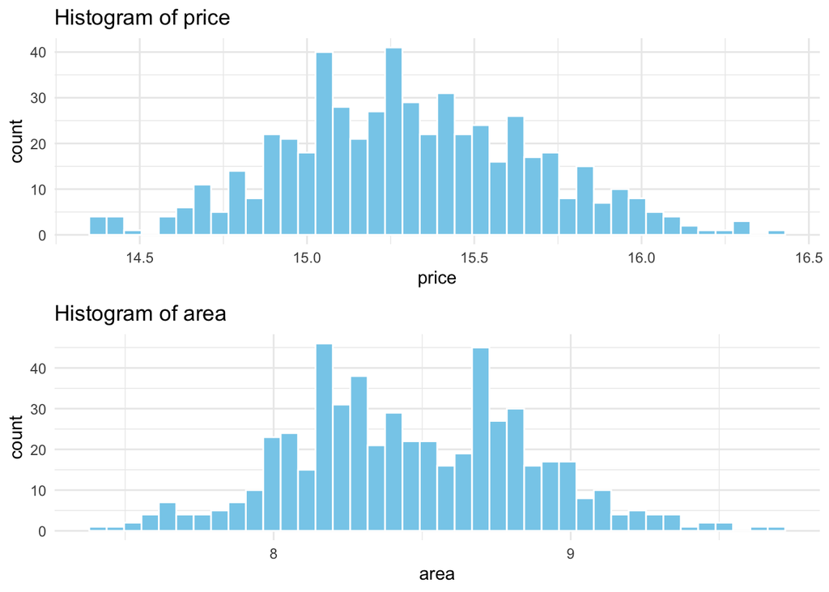

```r
plots <- list()

for (col in cols_num) {
  p <- ggplot(house_v2, aes(x = .data[[col]])) +
    geom_histogram(bins = 40, fill = "skyblue", color = "white") +
    labs(title = paste("Histogram of", col)) +
    theme_minimal()

  plots[[col]] <- p
}

grid.arrange(grobs = plots, ncol = 1) # Arrange all plots in a 1x3 grid
```

### 3.2 Distribution of categorical/factor variables

The categorical features in the dataset show clear patterns in the characteristics of the houses. Most properties have 3 bedrooms (55%) and 1 bathroom (74%), indicating that the dataset is dominated by moderately sized homes. Similarly, one- and two-story houses make up the majority (42% and 44%, respectively). Regarding amenities, a large proportion of homes are located on the main road (86%), while most do **not** have a guestroom (82%) or a basement (65%). Access to utilities and comfort features also shows strong trends: hot water heating is rare (5%), whereas air conditioning is present in about one-third of the homes (32%). Parking availability varies, with 55% having no dedicated parking, and the remainder split across one, two, or three parking spots.For external features, 77% of homes lack a prefarea (preferred area) designation, suggesting limited premium location attributes. With respect to furnishing, the dataset is fairly balanced: 42% semi-furnished, 33% unfurnished, and 26% furnished. Overall, these distributions indicate that the housing inventory is largely composed of modest, functional homes with limited luxury features and only moderate levels of furnishing and amenities.

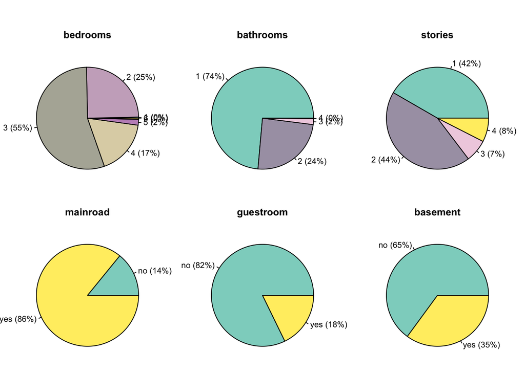

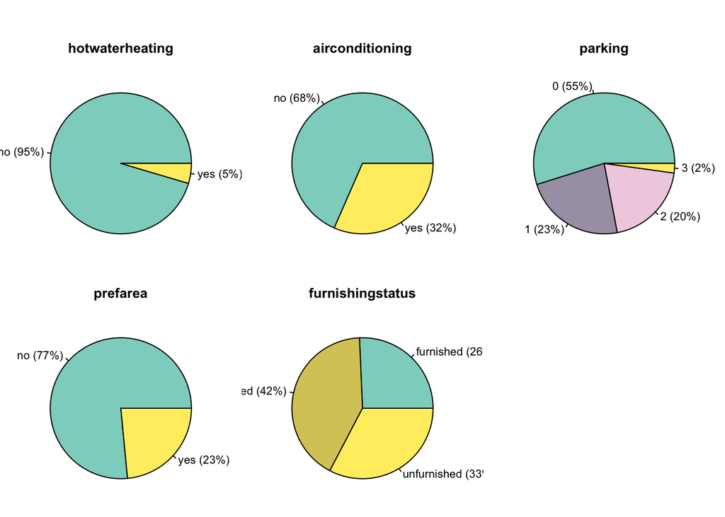

```r
cols_pie <- c('bedrooms', 'bathrooms', 'stories', 'mainroad', 'guestroom', 'basement','hotwaterheating','airconditioning','parking','prefarea','furnishingstatus')

par(mfrow = c(2, 3),
    #smaller margins
    mar   = c(1, 1, 3, 1),
    oma   = c(0, 0, 2, 0))

for (col in cols_pie) {
  counts <- table(house_v2[[col]])
  pct    <- round(100 * counts / sum(counts))
  lbls   <- paste0(names(counts), " (", pct, "%)") #format labels
  pal <- colorRampPalette(brewer.pal(12, "Set3"))(length(counts)) #color palette
  pie(counts,
      labels = lbls,
      main   = col,
      col    = pal)
}
```

### 3.3 Box plot `price` vs `categorical predictors`

This set of box plots provides a visual summary of how different **housing features** relate to the **log-transformed price** (labeled simply as “price” on the y-axis, but note the scale typically indicates a transformation) of a house. This interpretation is crucial for understanding which factors are the strongest predictors of house price. Here is an overall summary, interpreted for a final report: The analysis clearly indicates that **structural features** (Bedrooms, Bathrooms, Stories) and the presence of **key amenities** (Airconditioning, Mainroad access) are the most critical factors driving higher house prices. In contrast, **parking capacity** (beyond the first space) and **furnishing status** (especially semi-furnished vs. fully furnished) have a more moderate or complex relationship with the final price.

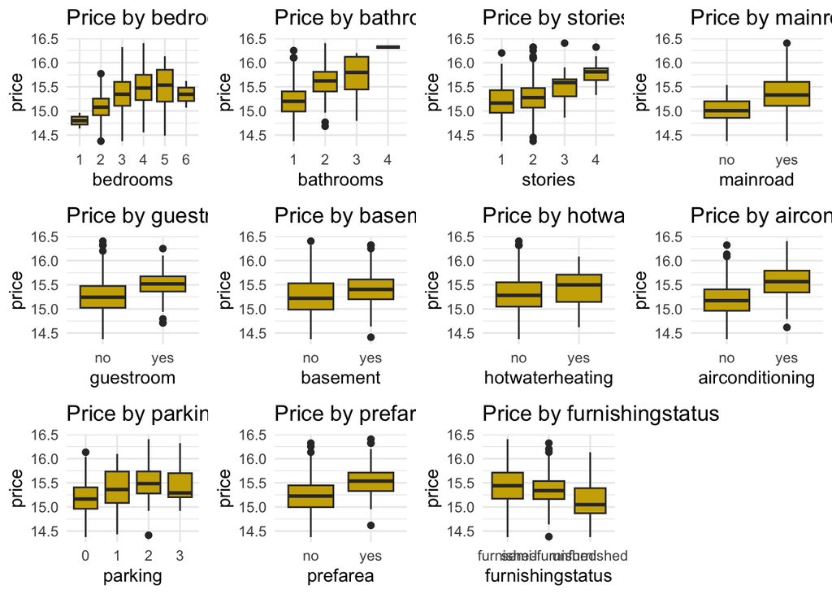

```r
cols_boxplot <- c('bedrooms', 'bathrooms', 'stories', 'mainroad', 'guestroom', 'basement','hotwaterheating','airconditioning','parking','prefarea','furnishingstatus')

plot_list <- list()

for (col in cols_boxplot) {
  p <- ggplot(house_v2, aes_string(x = col, y = "price")) +
    geom_boxplot(fill = "gold3") +
    labs(title = paste("Price by", col)) +
    theme_minimal()

  plot_list[[col]] <- p
}

grid.arrange(grobs = plot_list, ncol = 4) # Arrange all plots in a 2x3 grid
```

### 3.4 Scatter Plotting for `Price` vs `Area`

The scatter plot illustrates the relationship between property **Area** and **Price**, revealing a clear and expected **positive association**: larger properties tend to be priced higher. The price values appear within a narrow range, suggesting that the data has likely been log-transformed, which helps stabilize variance and highlight underlying trends. Overall, the pattern is **moderately strong and approximately linear**, indicating that Area is a meaningful predictor of Price. This visualization supports the use of regression modeling and aids in identifying any unusual observations, such as properties priced unusually high or low for their size. In summary, the plot confirms the intuitive and statistically useful finding that **price increases as area increases**, validating its importance in further modeling and decision-making. In short, the red line (regression line) is indicating that `Area` has visual linear effect on `Price`.

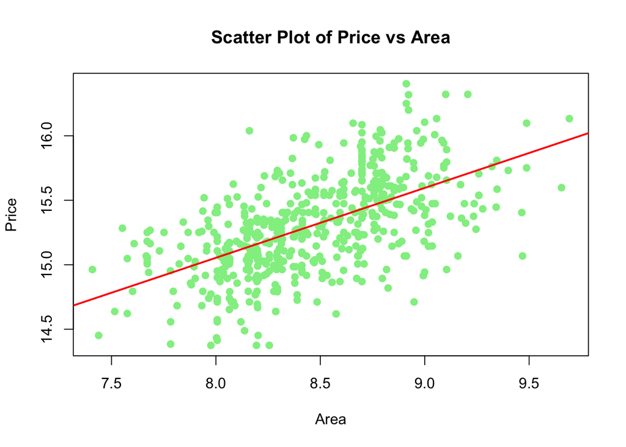

```r
plot(house_v2$area, house_v2$price,
     main = "Scatter Plot of Price vs Area",
     xlab = "Area",
     ylab = "Price",
     pch = 19,
     col = "lightgreen")
abline(lm(price ~ area, data = house_v2), col = "red", lwd = 2)
```

### 3.5 Correlation Matrix

The correlation matrix provides an initial assessment of how each housing feature is associated with the sale price( log-transformed). While correlations do not imply causation, they help identify predictors that may influence price and guide model selection. The key findings are summarized below:

**Key Findings**

### **1. Size and Structural Features**

- **Area** shows a **strong positive correlation (r=0.58)** with price, indicating that larger homes tend to be more expensive. This makes it one of the most important predictors.
- **Number of stories** displays a overall **moderate positive relationship (0 to 0.36)**, suggesting that multi-story homes generally command higher prices.
- **Number of Bedrooms** show only a overall **weak positive association (-0.37 to 0.22)**, meaning bedroom count alone is not a strong price driver compared to overall area or stories.

### **2. Home Quality and Amenities**

- **Bathrooms** have a **moderate positive correlation (0.12 to 0.44)** with price. Homes with two or more bathrooms tend to be priced notably higher.
- **Air conditioning** also has a **moderate positive association (~0.46)**, indicating that AC is a valuable feature in pricing.
- **Parking spaces** show a **weak to moderate positive correlation (0.13–0.30)**, meaning additional parking contributes to higher prices but not as strongly as interior features.

### **3. Location and Accessibility**

- **Main road access** exhibits a **moderate positive correlation (~0.33)**, suggesting that properties with direct access to main roads may be priced higher due to convenience.
- **Preferred area** has a similar **moderate positive correlation (~0.34)**, reinforcing the idea that location quality is an important price determinant.

### **4. Additional Features**

- Features like **guestroom (~0.28)**, **basement (~0.22)** shows moderately positive correlations, referring that these features also impact on the price of the house.
- **hotwaterheating (~0.09)** show **weak correlations**, implying limited independent effect on price.

### **5. Furnishing Status**

- **Semi-furnished** and **furnished** homes show a **weak to moderate positive relationship** with price.
- **Unfurnished** homes display a **negative correlation**, suggesting that furnished or semi-furnished properties tend to be valued higher than unfurnished ones.

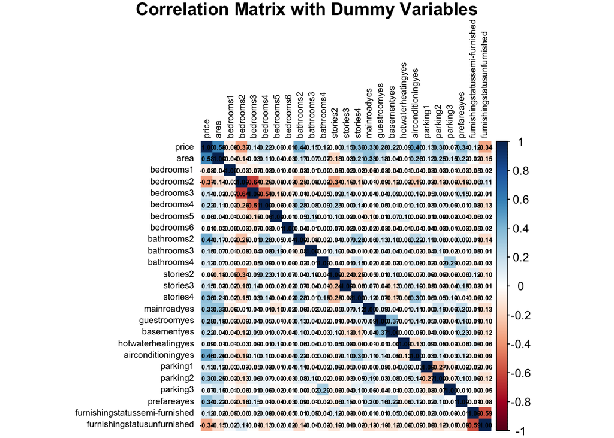

```r
# Convert factors to dummy variables
df_dummies <- model.matrix(~ . - 1, data = house_v2)
cor_matrix <- cor(df_dummies, use = "pairwise.complete.obs")

corrplot(cor_matrix,
         method = "color",
         addCoef.col = "black",
         number.cex = 0.45,
         tl.cex = 0.6,
         tl.col = "black",
         title = "Correlation Matrix with Dummy Variables",
         mar = c(0,0,1,0))
```

## 4. Feature Engineering and Data Split

### 4.1 Creating new variables

One new features was added: `Area_per_Room`. This variable provide alternative representations of space allocation that may offer a better predictive model.

```r
house_v3 <- house_v2 %>% mutate(
                                area_per_Room = area / (as.numeric(as.character(bedrooms)) + as.numeric(as.character(bathrooms)))
                                )
summary(house_v3)
```

```
##      price            area       bedrooms bathrooms stories mainroad  guestroom
##  Min.   :14.38   Min.   :7.409   1:  2    1:401     1:227   no : 77   no :448
##  1st Qu.:15.05   1st Qu.:8.189   2:136    2:133     2:238   yes:468   yes: 97
##  Median :15.28   Median :8.434   3:300    3: 10     3: 39
##  Mean   :15.31   Mean   :8.467   4: 95    4:  1     4: 41
##  3rd Qu.:15.56   3rd Qu.:8.758   5: 10
##  Max.   :16.40   Max.   :9.693   6:  2
##  basement  hotwaterheating airconditioning parking prefarea
##  no :354   no :520         no :373         0:299   no :417
##  yes:191   yes: 25         yes:172         1:126   yes:128
##                                            2:108
##                                            3: 12
##
##
##        furnishingstatus area_per_Room
##  furnished     :140     Min.   :1.046
##  semi-furnished:227     1st Qu.:1.740
##  unfurnished   :178     Median :2.071
##                         Mean   :2.102
##                         3rd Qu.:2.320
##                         Max.   :4.143
```

### 4.2 Train/Test Data Split

A 60/40 train–test split was created using a fixed seed for reproducibility. This ensures that the model is trained on one portion of the data while performance is evaluated on an independent subset.

```r
str(house_v3)
```

```
## 'data.frame':    545 obs. of  14 variables:
##  $ price           : num  16.4 16.3 16.3 16.3 16.3 ...
##  $ area            : num  8.91 9.1 9.21 8.92 8.91 ...
##  $ bedrooms        : Factor w/ 6 levels "1","2","3","4",..: 4 4 3 4 4 3 4 5 4 3 ...
##  $ bathrooms       : Factor w/ 4 levels "1","2","3","4": 2 4 2 2 1 3 3 3 1 2 ...
##  $ stories         : Factor w/ 4 levels "1","2","3","4": 3 4 2 2 2 1 4 2 2 4 ...
##  $ mainroad        : Factor w/ 2 levels "no","yes": 2 2 2 2 2 2 2 2 2 2 ...
##  $ guestroom       : Factor w/ 2 levels "no","yes": 1 1 1 1 2 1 1 1 2 2 ...
##  $ basement        : Factor w/ 2 levels "no","yes": 1 1 2 2 2 2 1 1 2 1 ...
##  $ hotwaterheating : Factor w/ 2 levels "no","yes": 1 1 1 1 1 1 1 1 1 1 ...
##  $ airconditioning : Factor w/ 2 levels "no","yes": 2 2 1 2 2 2 2 1 2 2 ...
##  $ parking         : Factor w/ 4 levels "0","1","2","3": 3 4 3 4 3 3 3 1 3 2 ...
##  $ prefarea        : Factor w/ 2 levels "no","yes": 2 1 2 2 1 2 2 1 2 2 ...
##  $ furnishingstatus: Factor w/ 3 levels "furnished","semi-furnished",..: 1 1 2 1 1 2 2 3 1 3 ...
##  $ area_per_Room   : num  1.49 1.14 1.84 1.49 1.78 ...
```

```r
# Set seed for reproducibility
set.seed(1)

# Create training (70%) and testing (30%) sets
train_index <- createDataPartition(house_v3$price, p = 0.6, list = FALSE)
train_data <- house_v3[train_index, ]
test_data <- house_v3[-train_index, ]

x_train <- model.matrix(price ~ ., data = train_data)[, -1]
y_train <- train_data$price

x_test  <- model.matrix(price ~ ., data = test_data)[, -1]
y_test  <- test_data$price

# Performance function
# Calculates performance across resamples: postResample(pred, obs)
# it calculates "mean squared error(MSE) and R-squared (R2) are calculated"

model_performance <- function(actual, predicted) {
                                                  postResample(pred = predicted, obs = actual)
                                                 }
```

```r
# to check the split dataset class by using 'concatenate and print' function cat()
cat("Class of train_data:==>",class(train_data),'\n')
```

```
## Class of train_data:==> data.frame
```

```r
cat("Class of train_data:==>",class(test_data),'\n')
```

```
## Class of train_data:==> data.frame
```

```r
cat("Class of train_data:==>",class(x_train),'\n')
```

```
## Class of train_data:==> matrix array
```

```r
cat("Class of train_data:==>",class(y_train),'\n')
```

```
## Class of train_data:==> numeric
```

```r
cat("Class of train_data:==>",class(x_test),'\n')
```

```
## Class of train_data:==> matrix array
```

```r
cat("Class of train_data:==>",class(y_test),'\n')
```

```
## Class of train_data:==> numeric
```

## 5. Modeling

### 5.1 Multiple Linear Regression

**Overall model significance:** the model is highly significant (F-statistic=33.02, p-value<2.2e-16), meaning that at least one of the predictors have significant relationship with the response variable `price`.

**Model Fit:** Multiple R<sup>2</sup>= 0.7227 explains approximately 72.27% of the variance in the dependent variables. And Adjusted R<sup>2</sup>=0.7008 means after adjusting for the number of predictors, the model explains about 70.08% of the variance. This indicating a resonably strong fit for real estate data.

**Prediction Accuracy (for test dataset) :** RMSE=0.2072, it shows the predictions deviate from actual values by about 0.2072 units (in the scale of the response variable). And MAE, mean absolute error is about 0.1550

```r
lm_model <- lm(price ~ ., data = train_data)
summary(lm_model)
```

```
##
## Call:
## lm(formula = price ~ ., data = train_data)
##
## Residuals:
##      Min       1Q   Median       3Q      Max
## -0.57446 -0.12768  0.00466  0.13213  0.56494
##
## Coefficients:
##                                 Estimate Std. Error t value Pr(>|t|)
## (Intercept)                    12.284177   0.580754  21.152  < 2e-16 ***
## area                            0.334112   0.070364   4.748 3.16e-06 ***
## bedrooms2                      -0.030346   0.363258  -0.084 0.933478
## bedrooms3                      -0.026886   0.516243  -0.052 0.958499
## bedrooms4                      -0.068103   0.600175  -0.113 0.909732
## bedrooms5                      -0.061456   0.653044  -0.094 0.925086
## bedrooms6                       0.235503   0.695552   0.339 0.735156
## bathrooms2                      0.154596   0.103687   1.491 0.136999
## bathrooms3                      0.276140   0.183270   1.507 0.132916
## bathrooms4                      0.612431   0.295559   2.072 0.039098 *
## stories2                        0.109768   0.030597   3.588 0.000389 ***
## stories3                        0.222674   0.050892   4.375 1.67e-05 ***
## stories4                        0.251073   0.057335   4.379 1.64e-05 ***
## mainroadyes                     0.100059   0.039267   2.548 0.011320 *
## guestroomyes                    0.058554   0.034383   1.703 0.089587 .
## basementyes                     0.086890   0.027162   3.199 0.001525 **
## hotwaterheatingyes              0.089334   0.059783   1.494 0.136134
## airconditioningyes              0.170589   0.028310   6.026 4.86e-09 ***
## parking1                        0.107938   0.030766   3.508 0.000519 ***
## parking2                        0.077762   0.032175   2.417 0.016243 *
## parking3                       -0.006260   0.088232  -0.071 0.943487
## prefareayes                     0.119509   0.029679   4.027 7.15e-05 ***
## furnishingstatussemi-furnished  0.003022   0.029538   0.102 0.918572
## furnishingstatusunfurnished    -0.099514   0.031223  -3.187 0.001586 **
## area_per_Room                  -0.055846   0.240794  -0.232 0.816753
## ---
## Signif. codes:  0 '***' 0.001 '**' 0.01 '*' 0.05 '.' 0.1 ' ' 1
##
## Residual standard error: 0.2063 on 304 degrees of freedom
## Multiple R-squared:  0.7227, Adjusted R-squared:  0.7008
## F-statistic: 33.02 on 24 and 304 DF,  p-value: < 2.2e-16
```

```r
lm_pred <- predict(lm_model, newdata = test_data)
lm_perf <- model_performance(y_test, lm_pred)
lm_perf
```

```
##      RMSE  Rsquared       MAE
## 0.2072180 0.6786913 0.1550338
```

```r
vif(lm_model) #check multicollinearity
```

```
##                        GVIF Df GVIF^(1/(2*Df))
## area               6.318707  1        2.513704
## bedrooms          95.346342  5        1.577358
## bathrooms         22.244112  3        1.677011
## stories            2.459004  3        1.161787
## mainroad           1.273096  1        1.128315
## guestroom          1.253902  1        1.119778
## basement           1.321636  1        1.149624
## hotwaterheating    1.125774  1        1.061025
## airconditioning    1.332529  1        1.154352
## parking            1.573824  3        1.078515
## prefarea           1.242553  1        1.114699
## furnishingstatus   1.174172  2        1.040957
## area_per_Room    107.357566  1       10.361350
```

### 5.2 LogPrice

With compared of previous linear model `lm_model`, Applying a log transformation to `Price` results approximately same 72% of the variance in `price`, and a slightly lower the Adjusted R<sup>2</sup> =0.6995 and modestly improve of residual error for test dataset (RMSE=0.2069), indicating slightly improvement over the previous linear model `lm_model`. However, it is the same statistically significant overall F-test. Same predictors become significant under the transformed scale too. So, the log-transformed model provided somehow more intuitive and economically sensible coefficient estimates.

```r
lm_log_model <- lm(log(price) ~ ., data = train_data)
summary(lm_log_model)
```

```
##
## Call:
## lm(formula = log(price) ~ ., data = train_data)
##
## Residuals:
##       Min        1Q    Median        3Q       Max
## -0.037963 -0.008249  0.000363  0.008519  0.036209
##
## Coefficients:
##                                  Estimate Std. Error t value Pr(>|t|)
## (Intercept)                     2.5290592  0.0380054  66.545  < 2e-16 ***
## area                            0.0216414  0.0046048   4.700 3.95e-06 ***
## bedrooms2                      -0.0008942  0.0237721  -0.038 0.970020
## bedrooms3                      -0.0001975  0.0337837  -0.006 0.995340
## bedrooms4                      -0.0027478  0.0392763  -0.070 0.944272
## bedrooms5                      -0.0021373  0.0427361  -0.050 0.960147
## bedrooms6                       0.0174480  0.0455179   0.383 0.701749
## bathrooms2                      0.0102843  0.0067854   1.516 0.130647
## bathrooms3                      0.0183444  0.0119934   1.530 0.127171
## bathrooms4                      0.0390908  0.0193418   2.021 0.044150 *
## stories2                        0.0071611  0.0020023   3.576 0.000405 ***
## stories3                        0.0145800  0.0033305   4.378 1.65e-05 ***
## stories4                        0.0163493  0.0037521   4.357 1.80e-05 ***
## mainroadyes                     0.0067587  0.0025697   2.630 0.008968 **
## guestroomyes                    0.0038255  0.0022501   1.700 0.090119 .
## basementyes                     0.0057591  0.0017775   3.240 0.001328 **
## hotwaterheatingyes              0.0058208  0.0039123   1.488 0.137831
## airconditioningyes              0.0111013  0.0018526   5.992 5.85e-09 ***
## parking1                        0.0069933  0.0020134   3.473 0.000588 ***
## parking2                        0.0049812  0.0021056   2.366 0.018621 *
## parking3                       -0.0006735  0.0057741  -0.117 0.907226
## prefareayes                     0.0077516  0.0019422   3.991 8.25e-05 ***
## furnishingstatussemi-furnished  0.0003581  0.0019330   0.185 0.853145
## furnishingstatusunfurnished    -0.0065569  0.0020433  -3.209 0.001474 **
## area_per_Room                  -0.0030166  0.0157579  -0.191 0.848313
## ---
## Signif. codes:  0 '***' 0.001 '**' 0.01 '*' 0.05 '.' 0.1 ' ' 1
##
## Residual standard error: 0.0135 on 304 degrees of freedom
## Multiple R-squared:  0.7215, Adjusted R-squared:  0.6995
## F-statistic: 32.81 on 24 and 304 DF,  p-value: < 2.2e-16
```

```r
# Predict in log space, then back-transform
lm_log_pred_log <- predict(lm_log_model, newdata = test_data)
lm_log_pred     <- exp(lm_log_pred_log)

lm_log_perf <- model_performance(y_test, lm_log_pred)
lm_log_perf
```

```
##      RMSE  Rsquared       MAE
## 0.2068654 0.6798208 0.1548971
```

```r
#check multicollinearity
vif(lm_log_model)
```

```
##                        GVIF Df GVIF^(1/(2*Df))
## area               6.318707  1        2.513704
## bedrooms          95.346342  5        1.577358
## bathrooms         22.244112  3        1.677011
## stories            2.459004  3        1.161787
## mainroad           1.273096  1        1.128315
## guestroom          1.253902  1        1.119778
## basement           1.321636  1        1.149624
## hotwaterheating    1.125774  1        1.061025
## airconditioning    1.332529  1        1.154352
## parking            1.573824  3        1.078515
## prefarea           1.242553  1        1.114699
## furnishingstatus   1.174172  2        1.040957
## area_per_Room    107.357566  1       10.361350
```

### 5.3 LogPrice + interactions

```r
lm_log_int_model <- lm(log(price) ~ area+guestroom*hotwaterheating + parking*prefarea+furnishingstatus*area_per_Room, data = train_data)
summary(lm_log_int_model)
```

```
##
## Call:
## lm(formula = log(price) ~ area + guestroom * hotwaterheating +
##     parking * prefarea + furnishingstatus * area_per_Room, data = train_data)
##
## Residuals:
##       Min        1Q    Median        3Q       Max
## -0.047449 -0.009385  0.000655  0.009451  0.035435
##
## Coefficients:
##                                                Estimate Std. Error t value
## (Intercept)                                   2.5208137  0.0215607 116.917
## area                                          0.0283010  0.0024868  11.380
## guestroomyes                                  0.0081629  0.0025329   3.223
## hotwaterheatingyes                            0.0034002  0.0046418   0.733
## parking1                                      0.0091078  0.0025973   3.507
## parking2                                      0.0072415  0.0028689   2.524
## parking3                                      0.0056837  0.0073945   0.769
## prefareayes                                   0.0113907  0.0029559   3.854
## furnishingstatussemi-furnished               -0.0057551  0.0094262  -0.611
## furnishingstatusunfurnished                  -0.0079748  0.0099883  -0.798
## area_per_Room                                -0.0169216  0.0032338  -5.233
## guestroomyes:hotwaterheatingyes              -0.0014830  0.0168593  -0.088
## parking1:prefareayes                         -0.0058119  0.0054081  -1.075
## parking2:prefareayes                         -0.0044830  0.0050465  -0.888
## parking3:prefareayes                         -0.0049025  0.0136751  -0.358
## furnishingstatussemi-furnished:area_per_Room  0.0016203  0.0044508   0.364
## furnishingstatusunfurnished:area_per_Room    -0.0004128  0.0045806  -0.090
##                                              Pr(>|t|)
## (Intercept)                                   < 2e-16 ***
## area                                          < 2e-16 ***
## guestroomyes                                 0.001404 **
## hotwaterheatingyes                           0.464399
## parking1                                     0.000520 ***
## parking2                                     0.012095 *
## parking3                                     0.442687
## prefareayes                                  0.000141 ***
## furnishingstatussemi-furnished               0.541949
## furnishingstatusunfurnished                  0.425236
## area_per_Room                                3.07e-07 ***
## guestroomyes:hotwaterheatingyes              0.929962
## parking1:prefareayes                         0.283353
## parking2:prefareayes                         0.375042
## parking3:prefareayes                         0.720212
## furnishingstatussemi-furnished:area_per_Room 0.716072
## furnishingstatusunfurnished:area_per_Room    0.928244
## ---
## Signif. codes:  0 '***' 0.001 '**' 0.01 '*' 0.05 '.' 0.1 ' ' 1
##
## Residual standard error: 0.01585 on 312 degrees of freedom
## Multiple R-squared:  0.6061, Adjusted R-squared:  0.5859
## F-statistic:    30 on 16 and 312 DF,  p-value: < 2.2e-16
```

```r
# Predict in log space, then back-transform
lm_log_int_pred_log <- predict(lm_log_int_model, newdata = test_data)
lm_log_int_pred     <- exp(lm_log_int_pred_log)

lm_log_int_perf <- model_performance(y_test, lm_log_int_pred)
lm_log_int_perf
```

```
##      RMSE  Rsquared       MAE
## 0.2388981 0.5708084 0.1871485
```

### 5.4 LASSO

The LASSO model was fit using 10-fold cross-validation to select the optimal regularization parameter. The model reduces several coefficients toward 0 as expected, and the resulting test performance (RMSE≈ 0.2062) is slightly better to the MLR models, indicating that LASSO does not substantially improve predictive accuracy.

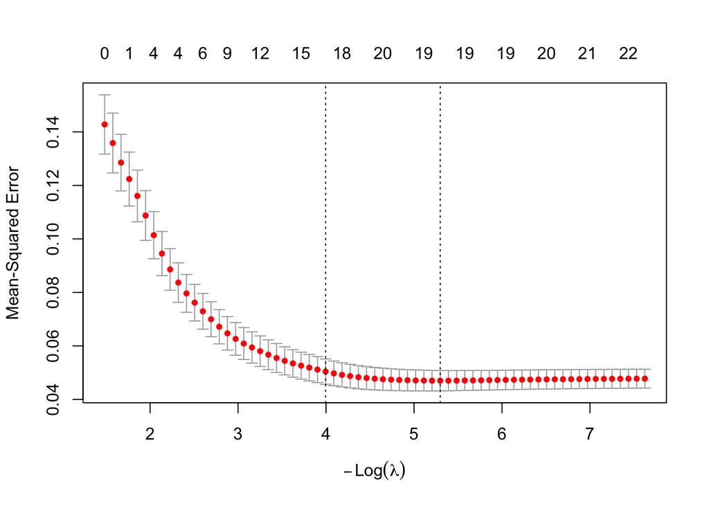

```r
set.seed(1)
# LASSO
lasso_cv <- cv.glmnet(x_train,
                      y_train,
                      alpha = 1,
                      nfolds = 10
                     )

plot(lasso_cv)
```

```r
lasso_model <- glmnet(x_train,
                      y_train,
                      alpha = 1,
                      lambda = lasso_cv$lambda.min
                      )

lasso_pred <- predict(lasso_model, newx = x_test)
lasso_perf <- model_performance(y_test, as.numeric(lasso_pred))
lasso_perf
```

```
##      RMSE  Rsquared       MAE
## 0.2061556 0.6802459 0.1529863
```

### 5.5 Ridge

Ridge regression was tuned using 10-fold cross-validation to select the optimal penalty value. The model stabilizes coefficient estimates as expected, but the test results (RMSE ≈ 0.2042 and R² ≈ 0.6862) show little improvement compared with the previous linear and LASSO models, indicating that Ridge does not substantially improve predictive accuracy.

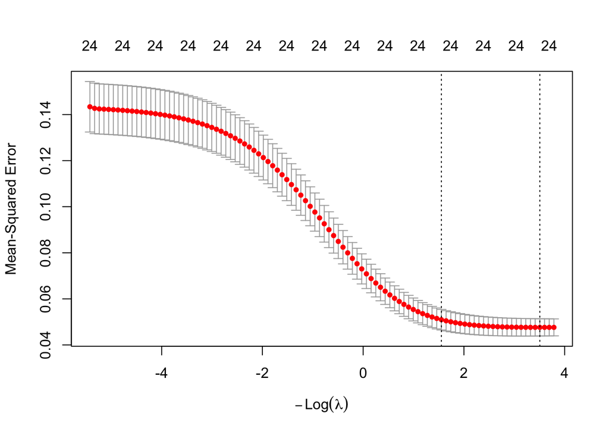

```r
set.seed(1)
# Ridge
ridge_cv <- cv.glmnet(x_train,
                      y_train,
                      alpha = 0,
                      nfolds = 10
                      )

plot(ridge_cv)
```

```r
ridge_model <- glmnet(x_train,
                      y_train,
                      alpha = 0,
                      lambda = ridge_cv$lambda.min
                      )

ridge_pred <- predict(ridge_model, newx = x_test)
ridge_perf <- model_performance(y_test, as.numeric(ridge_pred))
ridge_perf
```

```
##      RMSE  Rsquared       MAE
## 0.2042400 0.6861635 0.1514501
```

### 5.6 Elastic Net

Elastic Net, which combines both LASSO and Ridge penalties, was tuned using 10-fold cross-validation to select its optimal regularization strength. The model performs similarly to the individual LASSO and Ridge models, with test metrics (RMSE ≈ 0.2058 and R² ≈ 0.6813) showing only minimal improvement. This indicates that blending the two regularization methods does not substantially enhance predictive accuracy.

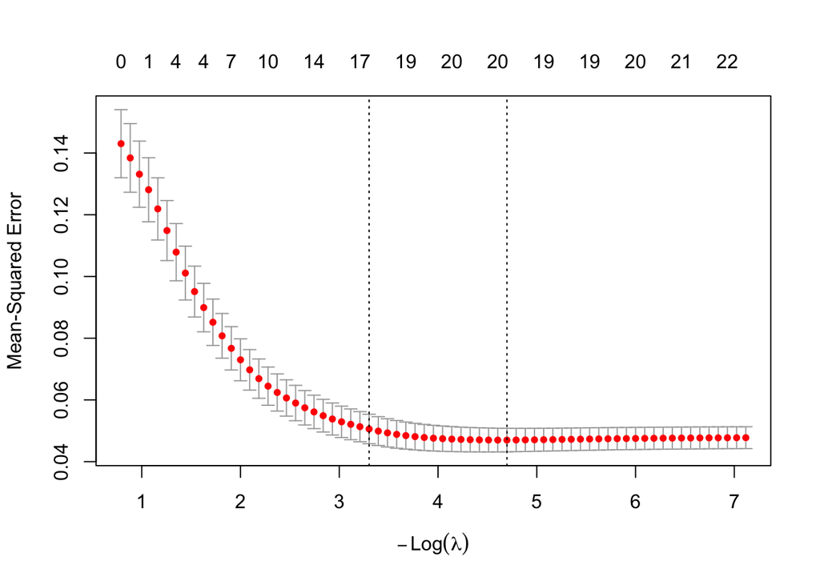

```r
set.seed(1)
# mix of LASSO and Ridge
elastic_cv <- cv.glmnet(x_train,
                        y_train,
                        alpha = 0.5,
                        nfolds = 10
                        )

plot(elastic_cv)
```

```r
elastic_model <- glmnet(x_train,
                        y_train,
                        alpha = 0.5,
                        lambda = elastic_cv$lambda.min
                        )

elastic_pred <- predict(elastic_model, newx = x_test)
elastic_perf <- model_performance(y_test, as.numeric(elastic_pred))
elastic_perf
```

```
##      RMSE  Rsquared       MAE
## 0.2058028 0.6813397 0.1526492
```

### 5.7 Random Forest

The random forest model was trained with 500 trees and a default heuristic for the number of variables considered at each split. The overall predictive performance slightly lower, with a test RMSE ≈0.2129 and an R² ≈0.6660. This indicates that the random forest does capture meaningful nonlinear relationships in the data and performs similarly to the earlier linear and regularized models.

```r
set.seed(1)
rf_model <- randomForest(price ~.,
                         data = train_data,
                         ntree = 500,
                         mtry  = floor(sqrt(ncol(train_data) - 1)),  # simple heuristic
                         importance = TRUE
                        )

print(rf_model)
```

```
##
## Call:
##  randomForest(formula = price ~ ., data = train_data, ntree = 500,      mtry = floor(sqrt(ncol(train_data) - 1)), importance = TRUE)
##                Type of random forest: regression
##                      Number of trees: 500
## No. of variables tried at each split: 3
##
##           Mean of squared residuals: 0.05079771
##                     % Var explained: 64.18
```

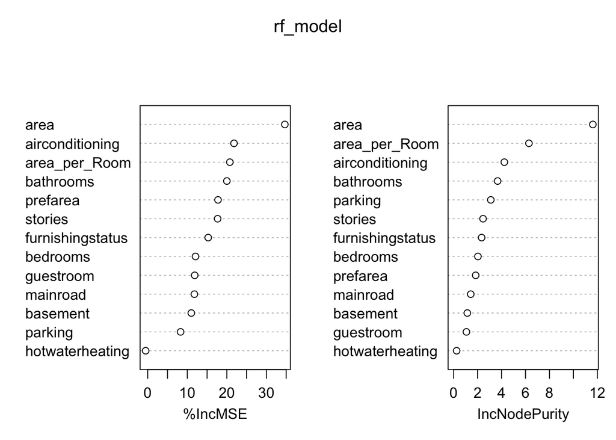

```r
varImpPlot(rf_model)
```

```r
rf_pred <- predict(rf_model, newdata = test_data)
rf_perf <- model_performance(test_data$price, rf_pred)
rf_perf
```

```
##      RMSE  Rsquared       MAE
## 0.2128915 0.6660377 0.1576372
```

### 5.8 Gradient Boosting

Gradient boosting highlights `area`, `area_per_Room`, `airconditioning` & `bathrooms` as the most influential predictors. However, test performance (RMSE ≈ 0.2204, R² ≈ 0.6431) is similar to the other models, indicating that boosting does not yield a meaningful improvement in predictive accuracy for this dataset.

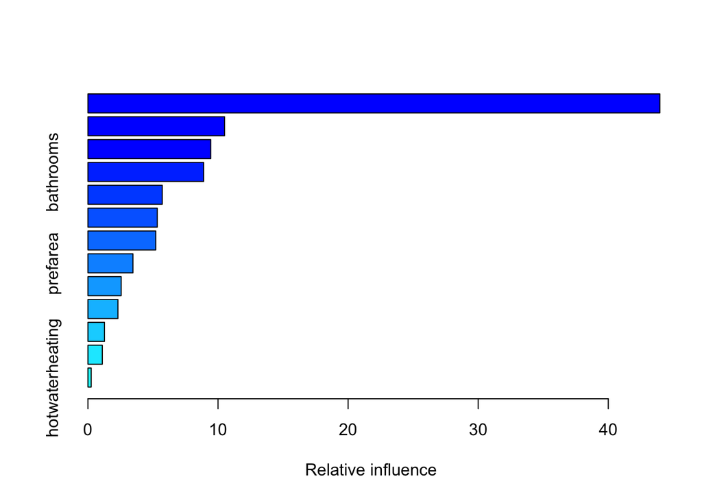

```
##                               var   rel.inf
## area                         area 43.967928
## area_per_Room       area_per_Room 10.502210
## airconditioning   airconditioning  9.438974
## bathrooms               bathrooms  8.896988
## stories                   stories  5.713224
## parking                   parking  5.330210
## furnishingstatus furnishingstatus  5.214281
## prefarea                 prefarea  3.458947
## basement                 basement  2.553045
## mainroad                 mainroad  2.303655
## bedrooms                 bedrooms  1.269895
## guestroom               guestroom  1.102188
## hotwaterheating   hotwaterheating  0.248456
```

```r
set.seed(1)
gbm_model <- gbm(formula = price ~ .,
                 data    = train_data,
                 distribution = "gaussian",
                 n.trees     = 2000,
                 interaction.depth = 3,
                 shrinkage   = 0.01,
                 n.minobsinnode = 10,
                 bag.fraction = 0.8,
                 train.fraction = 1.0,
                 verbose = FALSE
                )

summary(gbm_model)
```

```r
best_iter <- gbm.perf(gbm_model,
                      method = "OOB",
                      plot.it = FALSE)

gbm_pred <- predict(gbm_model,
                    newdata = test_data,
                    n.trees = best_iter
                    )

gbm_perf <- model_performance(test_data$price, gbm_pred)
gbm_perf
```

```
##      RMSE  Rsquared       MAE
## 0.2204263 0.6430968 0.1656844
```

## 6. Interpretation and Model Selection

### 6.1 Model Comparison

Eight predictive models are evaluated to estimated housing price using RMSE, R<sup>2</sup>, and MAE. Error levels are very similar across models. RMSE range is between ~0.2042 - 0.2389, and MAE is around ~0.1515–0.1871.R² is slightly differ among models. The best model explains around 69% of the variance in `Price`, & lowest model explains 57% of the variance in price, indicating that there is about 12% difference between lowest and best models. Regularized linear models perform slightly better than plain OLS and tree-based models. Elastic Net, LASSO, and Ridge give the lowest RMSE and MAE, but the differences are practically small. Overall, these results suggest that all models explain more than 50% of the variance in `price` and Overall, all models demonstrate the ability to predict housing prices from the available data, with differences only in their relative levels of accuracy and model fit.

```r
model_results <- bind_rows(
  data.frame(Model = "Linear",        t(lm_perf)),
  data.frame(Model = "Log-Linear",    t(lm_log_perf)),
  data.frame(Model = "Log-Linear + Interactions", t(lm_log_int_perf)),
  data.frame(Model = "LASSO",         t(lasso_perf)),
  data.frame(Model = "Ridge",         t(ridge_perf)),
  data.frame(Model = "Elastic Net",   t(elastic_perf)),
  data.frame(Model = "Random Forest", t(rf_perf)),
  data.frame(Model = "Gradient Boosting", t(gbm_perf))
)

model_results <- model_results %>% arrange(RMSE)   # lower RMSE is better

model_results
```

```
##                       Model      RMSE  Rsquared       MAE
## 1                     Ridge 0.2042400 0.6861635 0.1514501
## 2               Elastic Net 0.2058028 0.6813397 0.1526492
## 3                     LASSO 0.2061556 0.6802459 0.1529863
## 4                Log-Linear 0.2068654 0.6798208 0.1548971
## 5                    Linear 0.2072180 0.6786913 0.1550338
## 6             Random Forest 0.2128915 0.6660377 0.1576372
## 7         Gradient Boosting 0.2204263 0.6430968 0.1656844
## 8 Log-Linear + Interactions 0.2388981 0.5708084 0.1871485
```

### 6.2 Selected model

All eight models are able to predict housing prices using the given dataset, but their performances differ slightly across the evaluation metrices. Overall, all differences in RMSE, R2, & MAE are modest, meaning that model choice is driven more by simplicity, stability, and interpretability than by accuracy alone.

Due to its superior predictive accuracy, simplicity, & robustness, Ridge Regression is selected as the best model.

### 6.3 Conclusion:

However, the overall R² values indicate that even the best model explains only a modest portion of the variability in housing prices, suggesting that key predictors may be missing or the dataset has limited predictive signal.

### 6.4 Limitations

The modeling results highlight several limitations of the dataset:

- **Limited Predictive Power:** The available predictors do not appear to capture the key factors that typically drive housing prices in the real world. Important variables such as detailed neighborhood attributes, proximity to services, and market conditions are missing.
- **Data Quality & Availiability:** The relationships between Price and the predictors could not explain more than 69% of variance in the price, suggest that the data quality and availability must be evaluate. Weak or noisy predictors reduce model accuracy and increase uncertainty in coefficient estimates.Also, the relationship is not linear or some important predictors are missing (eg lot size, neighborhood rating, renovations e.t.c.)
- **Required Better Predictor:** Because all models perform similarly and none achieve meaningful predictive accuracy, increasing model complexity is unlikely to provide substantial improvement without better predictors.
- **Limited Nonlinear sturcture:** Machine learning models like Random Forest and Gradient Boosting perform worse than expected, indicating that the dataset may lack strong nonlinear relationships. This limits the advantages of more complex models.
- **Multicollinearity Among Predictors:** Although regularized models help mitigate multicollinearity, correlated predictors still make it harder to determine the unique contribution of individual features.

  In summary, although Ridge Regression is reported as the selected model, the broader conclusion is that this dataset is not suitable for accurate house price prediction. Practical use would require collecting more informative variables or revisiting how the data were generated to ensure that realistic price–feature relationships exist.